## Background

This run uses ARI values derived from parameter sweeps meant to preserve the relationship of prevalence being twice incidence. Here we assume that 80% of the population is in the low risk category regardless of prevalence.

This work reads in two functions which initialize and high and low risk population. The low risk population is subject to a lower risk of infection initially. The high risk population has a higher ARI. We calculate the number of infections these individuals have by age group and TB prevalence.

The second step is to generate new infections over a one year time period and then deterministically creates active cases of disease using prespecified progression rates that are a function of the number of infections an individual has.

## Simulation Scenarios

We consider a set of prevalence values and associated ARI. We consider two scenarios about the population mixing: homogeneous mixing or a high and low risk exposure groups.

### Mixing assumptions

Following are these parameter assumptions:

| prevalence | mixing ARI low risk | mixing ARI high risk | overall ARI | prop. low risk | prop. high risk |
| --- | --- | --- | --- | --- | --- |
| 100 | 1.015 | 6.09 | 2.03 | 0.8 | 0.2 |
| 200 | 1.850 | 11.10 | 3.70 | 0.8 | 0.2 |
| 300 | 2.510 | 15.06 | 5.02 | 0.8 | 0.2 |
| 400 | 3.085 | 18.51 | 6.17 | 0.8 | 0.2 |
| 500 | 3.615 | 21.69 | 7.23 | 0.8 | 0.2 |
| 600 | 4.115 | 24.69 | 8.23 | 0.8 | 0.2 |
| 700 | 4.595 | 27.57 | 9.19 | 0.8 | 0.2 |
| 800 | 5.060 | 30.36 | 10.12 | 0.8 | 0.2 |
| 900 | 5.520 | 33.12 | 11.04 | 0.8 | 0.2 |
| 1000 | 5.970 | 35.82 | 11.94 | 0.8 | 0.2 |

### TB progression assumptions

We assume that the risk of TB progression varies with the number of prior infections. This assumes that there is protection, but that it wanes with an increasing number of infections (Ackley assumption).

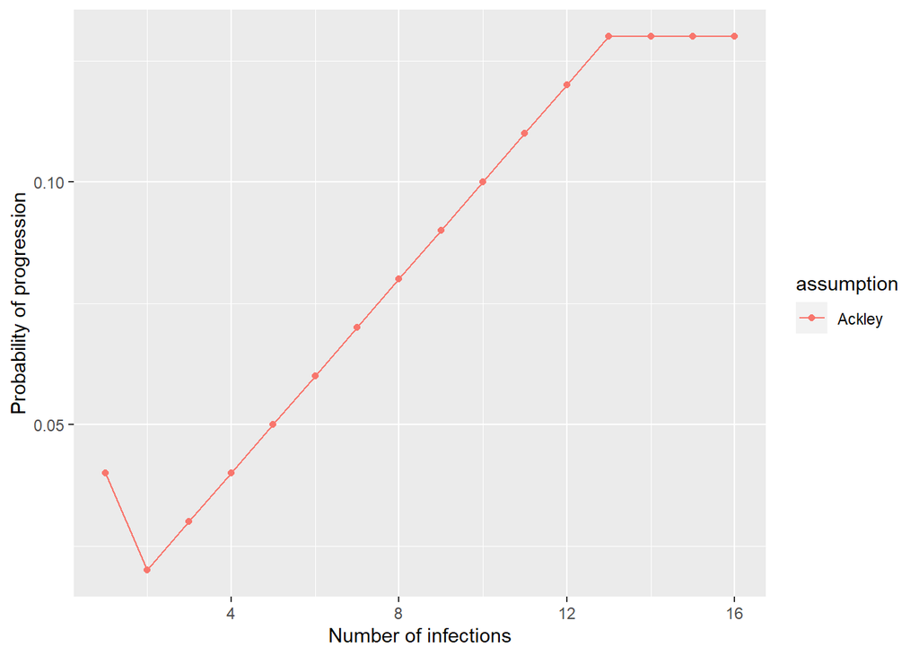

## Initializing the population

We first determine the number of infections that individuals have at the start of the simulation.

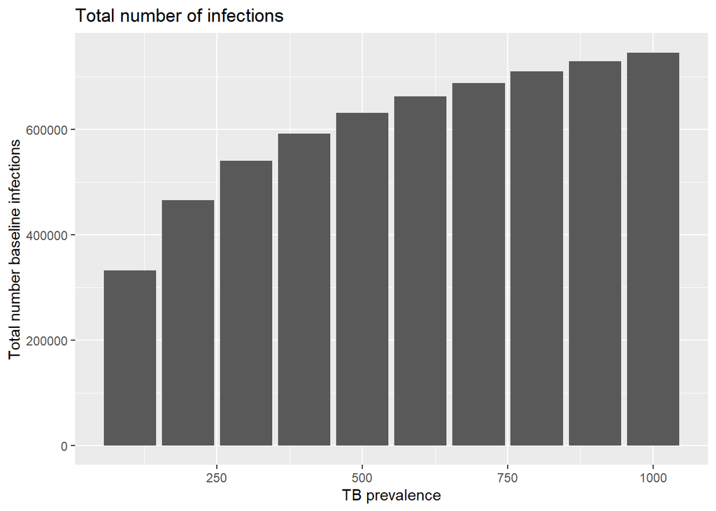

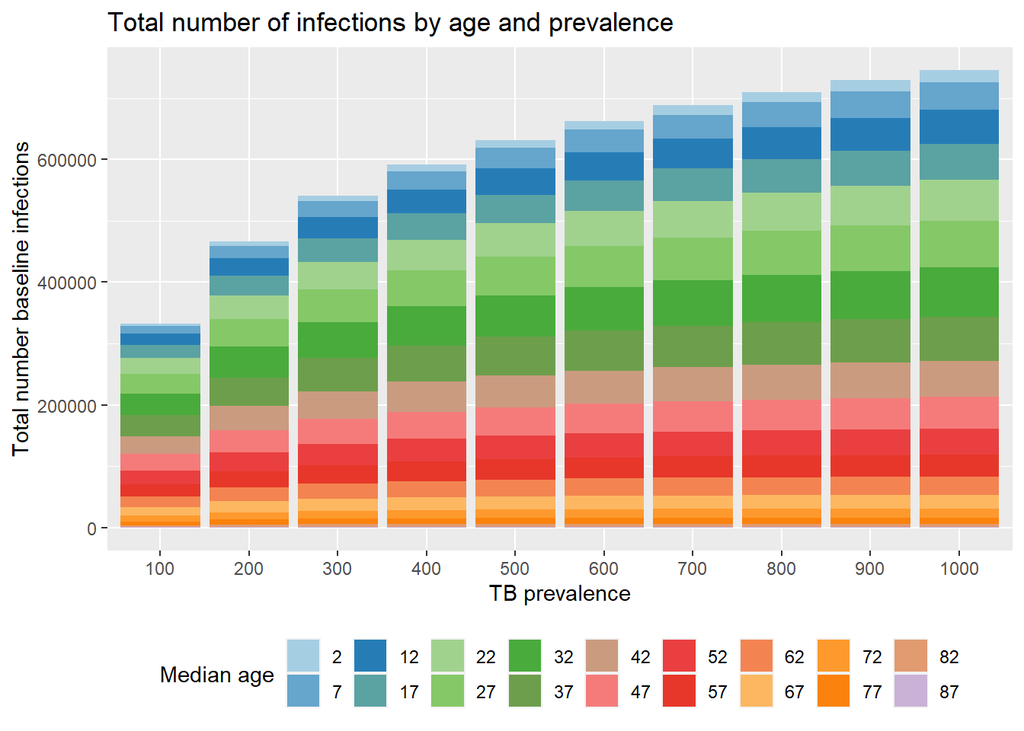

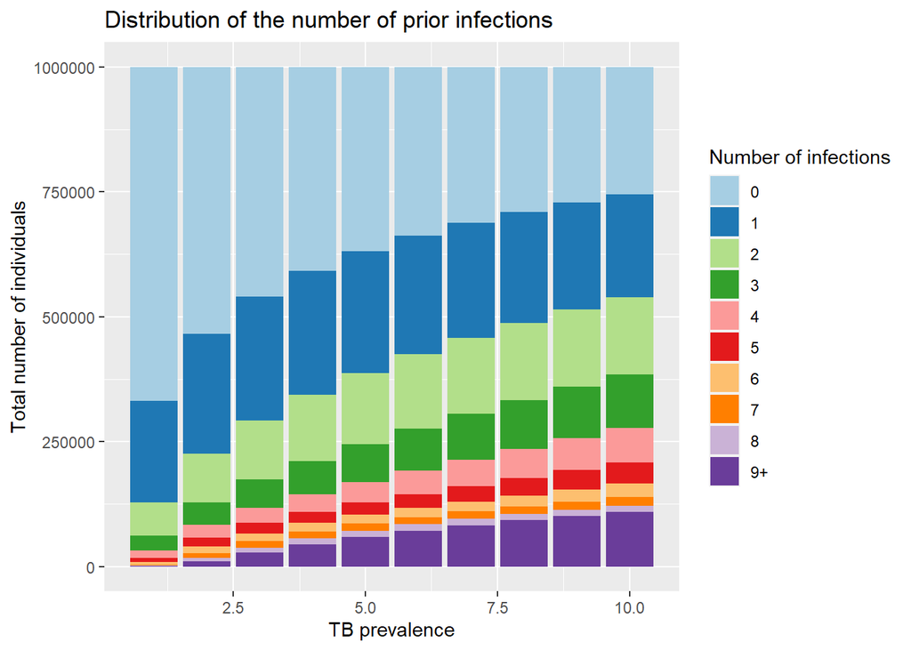

We focus in on those with at least six prior infections in this plot.

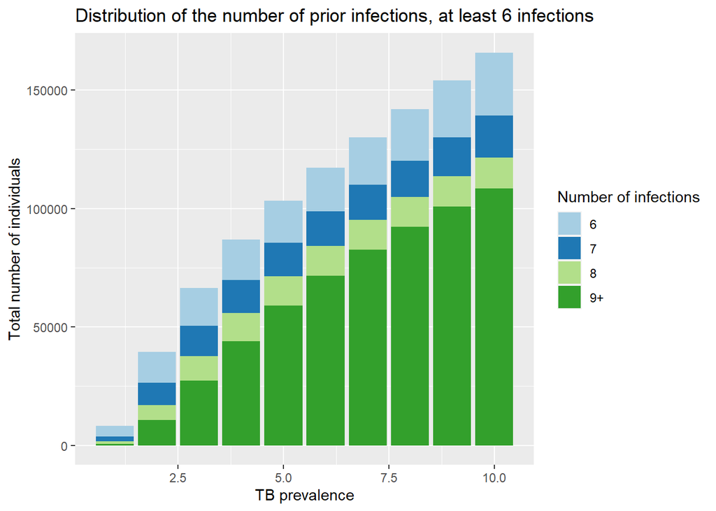

We show the prevalence of LTBI by age and TB disease prevalance. This can be compared to the Dodd et al data.

Prevalence of LTBI by age and TB prevalence

|  | Prev100 | Prev200 | Prev300 | Prev400 | Prev500 | Prev600 | Prev700 | Prev800 | Prev900 | Prev1000 |
| --- | --- | --- | --- | --- | --- | --- | --- | --- | --- | --- |
| 0-4 | 0.04 | 0.07 | 0.09 | 0.11 | 0.13 | 0.14 | 0.16 | 0.17 | 0.18 | 0.19 |
| 5-9 | 0.12 | 0.21 | 0.26 | 0.30 | 0.34 | 0.36 | 0.39 | 0.41 | 0.44 | 0.46 |
| 10-14 | 0.20 | 0.31 | 0.38 | 0.43 | 0.47 | 0.50 | 0.53 | 0.56 | 0.58 | 0.61 |
| 15-19 | 0.26 | 0.39 | 0.46 | 0.52 | 0.56 | 0.60 | 0.63 | 0.66 | 0.69 | 0.71 |
| 20-24 | 0.31 | 0.45 | 0.53 | 0.59 | 0.64 | 0.68 | 0.71 | 0.74 | 0.76 | 0.78 |
| 25-29 | 0.35 | 0.50 | 0.59 | 0.65 | 0.70 | 0.74 | 0.77 | 0.80 | 0.82 | 0.84 |
| 30-34 | 0.39 | 0.55 | 0.64 | 0.70 | 0.75 | 0.79 | 0.82 | 0.84 | 0.86 | 0.88 |
| 35-39 | 0.43 | 0.59 | 0.68 | 0.74 | 0.79 | 0.83 | 0.85 | 0.88 | 0.90 | 0.91 |
| 40-44 | 0.46 | 0.63 | 0.72 | 0.78 | 0.82 | 0.86 | 0.88 | 0.90 | 0.92 | 0.93 |
| 45-49 | 0.49 | 0.66 | 0.75 | 0.81 | 0.85 | 0.88 | 0.91 | 0.93 | 0.94 | 0.95 |
| 50-54 | 0.52 | 0.69 | 0.78 | 0.84 | 0.88 | 0.91 | 0.93 | 0.94 | 0.95 | 0.96 |
| 55-59 | 0.55 | 0.72 | 0.81 | 0.86 | 0.90 | 0.92 | 0.94 | 0.96 | 0.97 | 0.97 |
| 60-64 | 0.57 | 0.75 | 0.83 | 0.88 | 0.91 | 0.94 | 0.95 | 0.97 | 0.97 | 0.98 |
| 65=-69 | 0.59 | 0.77 | 0.85 | 0.90 | 0.93 | 0.95 | 0.96 | 0.97 | 0.98 | 0.99 |
| 70-74 | 0.61 | 0.79 | 0.87 | 0.91 | 0.94 | 0.96 | 0.97 | 0.98 | 0.98 | 0.99 |
| 75-79 | 0.63 | 0.81 | 0.88 | 0.93 | 0.95 | 0.97 | 0.98 | 0.98 | 0.99 | 0.99 |
| 80-84 | 0.65 | 0.82 | 0.90 | 0.94 | 0.96 | 0.97 | 0.98 | 0.99 | 0.99 | 0.99 |
| 85+ | 0.67 | 0.84 | 0.91 | 0.95 | 0.97 | 0.98 | 0.99 | 0.99 | 0.99 | 1.00 |

We also show the total number of infections and total number of times individuals have been infected by risk category.

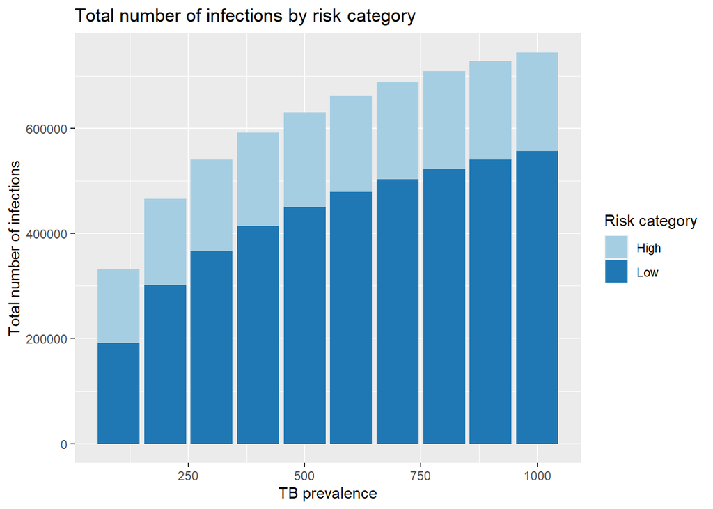

We can also consider the number of infections individuals have by prevalence and risk category.

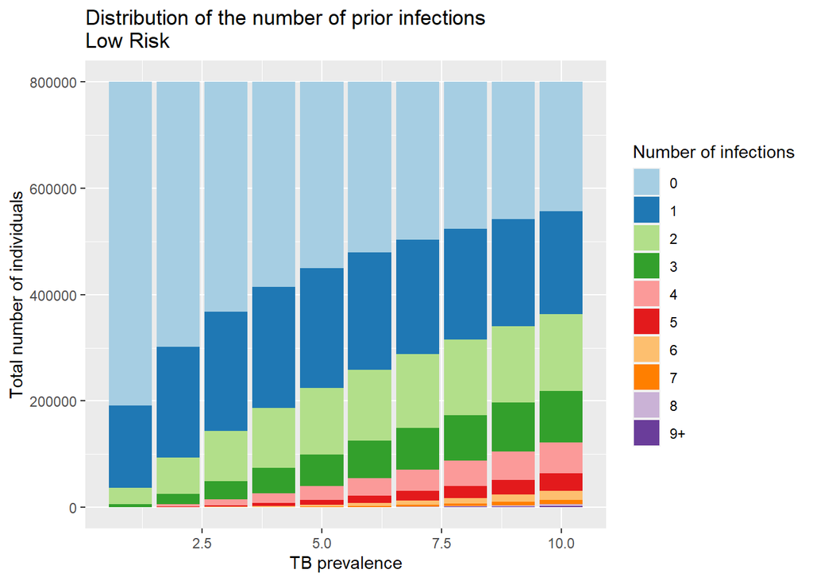

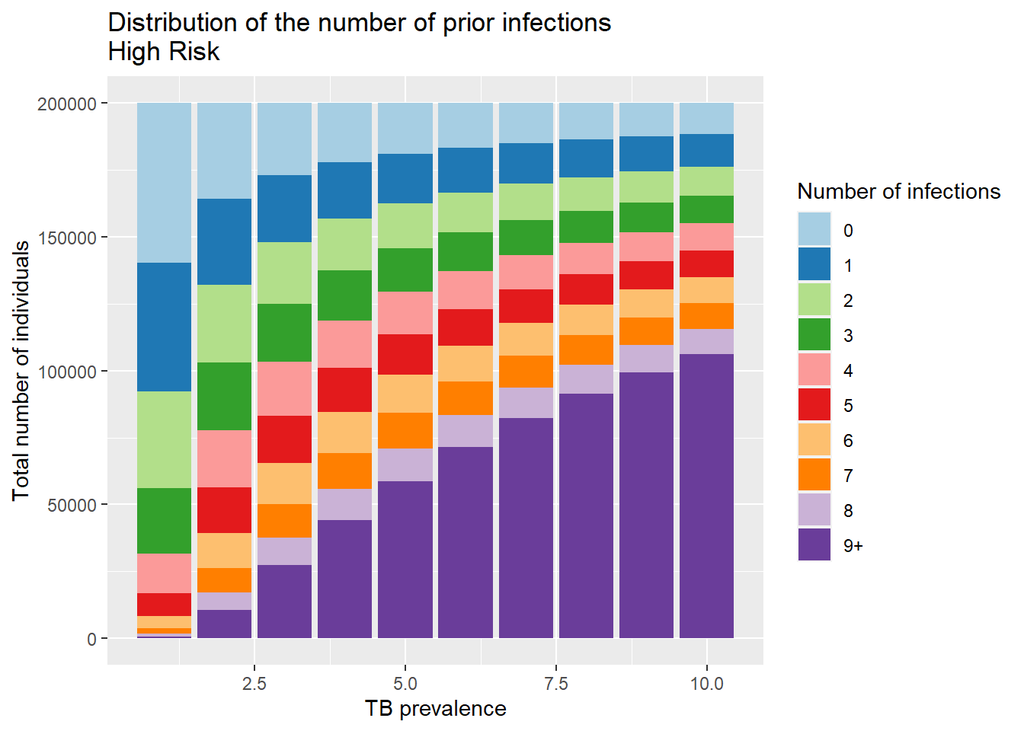

## New cases generated over one year

We now generate cases over a one year period. All infected individuals with no reinfection in this year have a 0.00075 probability of progressing to active disease. Individuals with a first infection have a 0.04 probability of progressing.

We can calculate the following statistics (the first 6 only apply to the mixing scenarios):

- Cases from first infection, low risk
- Cases from reinfection, low risk
- Total cases, low risk
- Cases from first infection, high risk
- Cases from reinfection, high risk
- Total cases, high risk
- Cases from old infection (all in high risk)
- Total cases
- percent cases from first infection
- percent cases from old infection
- Corrected prevalence (=1.66*smear positive prevalence)
- Incidence (per 100000)
- Implied duration (=prev/Inc)
- Reproductive number for infection (= #new infections/corrected prevalence)
- Reproductive number for disease (= #ATB from new infections/corrected prevalence)

### Mixing, Ackley

| low risk: ATB from first inf | low risk: ATB from reinfection | low risk: total ATB | high risk: ATB from first int | high risk: ATB from reinfection | high risk: total ATB | ATB from old infections | Total ATB | percent first inf | percent old inf | corrected prevalence | incidence (per 100,000) | duration | Rt infections | Rt disease |
| --- | --- | --- | --- | --- | --- | --- | --- | --- | --- | --- | --- | --- | --- | --- |
| 246.9583 | 43.25451 | 290.2128 | 145.8346 | 299.4791 | 445.3136 | 95.96519 | 831.4916 | 0.4723955 | 0.1154133 | 166 | 83.14916 | 1.996412 | 122.28916 | 4.430882 |
| 368.9345 | 134.81245 | 503.7469 | 158.6050 | 891.3915 | 1049.9966 | 106.55861 | 1660.3021 | 0.3177370 | 0.0641803 | 332 | 166.03021 | 1.999636 | 111.44578 | 4.679950 |
| 434.2454 | 237.74576 | 671.9912 | 162.7970 | 1547.4053 | 1710.2023 | 107.14145 | 2489.3349 | 0.2398401 | 0.0430402 | 498 | 248.93349 | 2.000534 | 100.80321 | 4.783521 |
| 476.2170 | 347.55556 | 823.7726 | 165.0172 | 2224.8762 | 2389.8933 | 105.51932 | 3319.1852 | 0.1931902 | 0.0317907 | 664 | 331.91852 | 2.000491 | 92.92169 | 4.839858 |
| 506.0773 | 464.50429 | 970.5816 | 166.2990 | 2911.9378 | 3078.2369 | 103.08922 | 4151.9077 | 0.1619440 | 0.0248294 | 830 | 415.19077 | 1.999081 | 87.10843 | 4.878094 |
| 528.4600 | 588.17428 | 1116.6343 | 166.9722 | 3598.4719 | 3765.4441 | 100.28485 | 4982.3632 | 0.1395788 | 0.0201280 | 996 | 498.23632 | 1.999051 | 82.63052 | 4.901685 |
| 545.9064 | 718.77122 | 1264.6776 | 167.1979 | 4281.8788 | 4449.0767 | 97.27409 | 5811.0284 | 0.1227157 | 0.0167396 | 1162 | 581.10284 | 1.999646 | 79.08778 | 4.917172 |
| 559.8684 | 856.16867 | 1416.0371 | 167.0673 | 4959.7455 | 5126.8128 | 94.14211 | 6636.9920 | 0.1095279 | 0.0141845 | 1328 | 663.69920 | 2.000906 | 76.20482 | 4.926845 |
| 571.4346 | 1002.47298 | 1573.9076 | 166.6319 | 5640.9529 | 5807.5847 | 90.88658 | 7472.3789 | 0.0987726 | 0.0121630 | 1494 | 747.23789 | 1.999363 | 73.89558 | 4.940758 |
| 581.0247 | 1155.47693 | 1736.5016 | 165.9358 | 6314.4098 | 6480.3456 | 87.58408 | 8304.4313 | 0.0899472 | 0.0105467 | 1660 | 830.44313 | 1.998933 | 71.92771 | 4.949908 |

### Plotting the results

We show the number of TB disease cases by prevalence and source (old infection, new primary infection, re-infection).

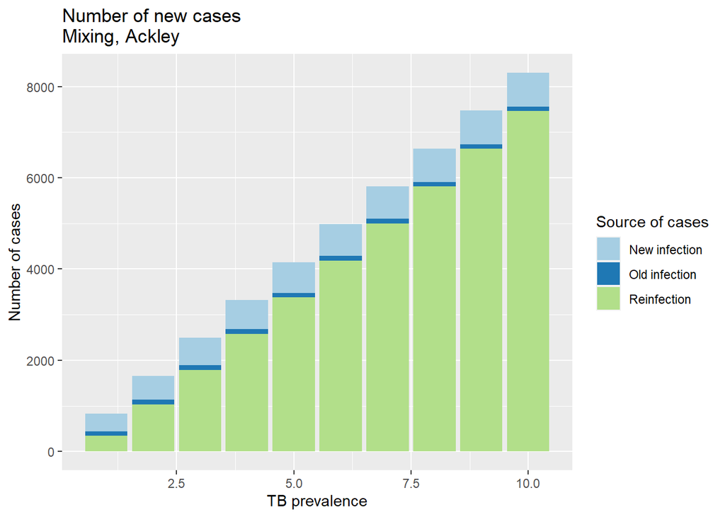